# PROSPER LOAN DATASET ANALYSIS

## by Amos Moses Omofaiye (UDACITY DAND SCHOLAR)

- Introduction
- Dataset Features
- Univariate Exploration
- Bivariate Exploration
- Multivariate Exploration
- Observations
- Conclusions
- References

### Introduction

> This dataset is on Loan and their outcomes. The loan disbursing organization is Prosper. This data set contains 113,937 loans with 81 variables on each loan, including loan amount, borrower rate (or interest rate), current loan status, borrower income, and many others. For this analysis, I will focus on the variables below. I believe I will be able to demonstrate my skills and come up with useful observations on the loan data.

> The variables are:
- Term: The length of the loan expressed in months.
- Loan Status: The current status of the loan: Cancelled, Chargedoff, Completed, Current, Defaulted, FinalPaymentInProgress, PastDue. The PastDue status will be accompanied by a delinquency bucket.
- BorrowerAPR: The Borrower's Annual Percentage Rate (APR) for the loan.
- ProsperScore: A custom risk score built using historical Prosper data. The score ranges from 1-10, with 10 being the best, or lowest risk score. Applicable for loans originated after July 2009.
- ListingCategory: The category of the listing that the borrower selected when posting their listing: 0 - Not Available, 1 - Debt Consolidation, 2 - Home Improvement, 3 - Business, 4 - Personal Loan, 5 - Student Use, 6 - Auto, 7- Other, 8 - Baby & Adoption, 9 - Boat, 10 - Cosmetic Procedure, 11 - Engagement Ring, 12 - Green Loans, 13 - Household Expenses, 14 - Large Purchases, 15 - Medical/Dental, 16 - Motorcycle, 17 - RV, 18 - Taxes, 19 - Vacation, 20 - Wedding Loans
- BorrowerState: The two letter abbreviation of the state of the address of the borrower at the time the Listing was created.
- Occupation: The Occupation selected by the Borrower at the time they created the listing.
- EmploymentStatusDuration: The length in months of the employment status at the time the listing was created.
- EmploymentStatus: The employment status of the borrower at the time they posted the listing.
- AvailableBankCardCredit: The total available credit via bank card at the time the credit profile was pulled.
- StatedMonthlyIncome: The monthly income the borrower stated at the time the listing was created.
- LoanNumber: Unique numeric value associated with the loan.
- LoanOriginationQuarter: The quarter in which the loan was originated.
- Recommendations: Number of recommendations the borrower had at the time the listing was created.

### Research Question

> I will be exploring based on the folowing broad research question:
> 1. What factors affect a loan’s status?

### Dataset Features

```python
# Now, I will import the necessary packages
import numpy as np
import pandas as pd
import matplotlib.pyplot as plt
import seaborn as sb
from pywaffle import Waffle
# Next, I want to set my plots to be embedded in this notebook (that is inline)
%matplotlib inline
# Finally, I will set the style for seaborn plots
sb.set_style("darkgrid")
```

> Next, I will load the dataset

```python
# Loading the prosper loan data set
df = pd.read_csv("prosperLoanData.csv")
```

```python
# Checking the first few rows of the dataset
df.head()
```

|  | ListingKey | ListingNumber | ListingCreationDate | CreditGrade | Term | LoanStatus | ClosedDate | BorrowerAPR | BorrowerRate | LenderYield | ... | LP_ServiceFees | LP_CollectionFees | LP_GrossPrincipalLoss | LP_NetPrincipalLoss | LP_NonPrincipalRecoverypayments | PercentFunded | Recommendations | InvestmentFromFriendsCount | InvestmentFromFriendsAmount | Investors |
| --- | --- | --- | --- | --- | --- | --- | --- | --- | --- | --- | --- | --- | --- | --- | --- | --- | --- | --- | --- | --- | --- |
| 0 | 1021339766868145413AB3B | 193129 | 2007-08-26 19:09:29.263000000 | C | 36 | Completed | 2009-08-14 00:00:00 | 0.16516 | 0.1580 | 0.1380 | ... | -133.18 | 0.0 | 0.0 | 0.0 | 0.0 | 1.0 | 0 | 0 | 0.0 | 258 |
| 1 | 10273602499503308B223C1 | 1209647 | 2014-02-27 08:28:07.900000000 | NaN | 36 | Current | NaN | 0.12016 | 0.0920 | 0.0820 | ... | 0.00 | 0.0 | 0.0 | 0.0 | 0.0 | 1.0 | 0 | 0 | 0.0 | 1 |
| 2 | 0EE9337825851032864889A | 81716 | 2007-01-05 15:00:47.090000000 | HR | 36 | Completed | 2009-12-17 00:00:00 | 0.28269 | 0.2750 | 0.2400 | ... | -24.20 | 0.0 | 0.0 | 0.0 | 0.0 | 1.0 | 0 | 0 | 0.0 | 41 |
| 3 | 0EF5356002482715299901A | 658116 | 2012-10-22 11:02:35.010000000 | NaN | 36 | Current | NaN | 0.12528 | 0.0974 | 0.0874 | ... | -108.01 | 0.0 | 0.0 | 0.0 | 0.0 | 1.0 | 0 | 0 | 0.0 | 158 |
| 4 | 0F023589499656230C5E3E2 | 909464 | 2013-09-14 18:38:39.097000000 | NaN | 36 | Current | NaN | 0.24614 | 0.2085 | 0.1985 | ... | -60.27 | 0.0 | 0.0 | 0.0 | 0.0 | 1.0 | 0 | 0 | 0.0 | 20 |

5 rows × 81 columns

```python
# Getting the shape of the dataset
df.shape
```

```
(113937, 81)
```

```python
# Getting the columns of the dataset. I will create a function that I can later call for similar cases
def column_lister(df):
    for i,v in enumerate(df.columns):
        print(i,v)
```

```python
# Listing the columns
column_lister(df)
```

```
0 ListingKey
1 ListingNumber
2 ListingCreationDate
3 CreditGrade
4 Term
5 LoanStatus
6 ClosedDate
7 BorrowerAPR
8 BorrowerRate
9 LenderYield
10 EstimatedEffectiveYield
11 EstimatedLoss
12 EstimatedReturn
13 ProsperRating (numeric)
14 ProsperRating (Alpha)
```

[output cut: 66 more lines]

### What is the structure of your dataset?

> The dataset has 113,937 rows and 81 columns. This makes it a whopping 113937 loans.

### What is/are the main feature(s) of interest in your dataset?

> The main feature of interest in this dataset is LoanStatus.

### What features in the dataset do you think will help support your investigation into your feature(s) of interest?

> I have selected features that I think will be useful in supporting my investigation of the LoanStatus. These features are:
> - Term
> - ProsperScore
> - Recommendations
> - StatedMonthlyIncome
> - BorrowerAPR
> - BorrowerState
> - Occupation
> - ListingCategory (numeric)
> - EmploymentStatus
> - EmploymentStatusDuration
> - AvailableBankcardCredit
> - StatedMonthlyIncome
> - LoanNumber
> - LoanOriginationQuarter

> These variables were explained in the introduction section.

### Univariate Exploration

> Now, I want to investigate the variables of interest one by one so as to get an overall look of the data.

```python
# First, I will make a copy of the dataset so as to ensure the original dataset remains the same.
# The copy will be called df1
df1 = df.copy()
```

```python
# Second, I will extract the variables of interest to another data frame for convinience. This data frame
# will be called df_prosper.
df_prosper = df1[["LoanStatus", "Term","ProsperScore", "Recommendations", "TotalTrades",
                 "StatedMonthlyIncome", "BorrowerAPR", "BorrowerState", "Occupation", "ListingCategory (numeric)",
                 "EmploymentStatus", "EmploymentStatusDuration", "AvailableBankcardCredit",
                 "StatedMonthlyIncome", "LoanNumber", "LoanOriginationQuarter"]]
```

```python
# The shape of df_prosper comare to df1
#df_prosper.shape, df1.shape
# I want to save the dataset for the variables of interest before I move ahead
#df_prosper.to_csv("prosper_extract.csv", index=False)
#df_prosper = pd.read_csv("prosper_extract.csv")
```

```python
# Next, I will look at the data types of the variables in order to better inform my plots
df_prosper.dtypes
```

```
LoanStatus                    object
Term                           int64
ProsperScore                 float64
Recommendations                int64
TotalTrades                  float64
StatedMonthlyIncome          float64
BorrowerAPR                  float64
BorrowerState                 object
Occupation                    object
ListingCategory (numeric)      int64
EmploymentStatus              object
EmploymentStatusDuration     float64
AvailableBankcardCredit      float64
StatedMonthlyIncome.1        float64
LoanNumber                     int64
LoanOriginationQuarter        object
dtype: object
```

```python
df_prosper.shape
```

```
(113937, 16)
```

> It appears these data types are okay for now and I will therefore make use of the appropriate plot for each type. I will use different plots for the qualitative and the quantitative data type. Shall we continue?

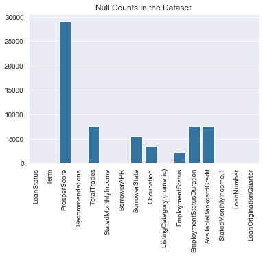

```python
# Checking for missing values
df_prosper.isnull().sum() #There are many nulls, I want to visualize them
null_counts = df_prosper.isnull().sum()
color = sb.color_palette()[0]
sb.barplot(null_counts.index.values, null_counts, color=color)
plt.title("Null Counts in the Dataset")
plt.xticks(rotation=90);
```

> As can be seen, the ProsperScore column has huge numbers of nulls. These nulls are about 30,000. The others like TotalTrades, EmploymentStatusDuration, and AvailableBankcardCredit each has about 8000 nulls. Because the three are roughly the same, I can say these nulls are not random. I do not plan to fill them with any number because filing arbitrarily may distort the analysis. So, I will drop the ProsperScore column and drop the nulls in the remaining columns.

```python
# Dropping the ProsperScore column
df_prosper.drop(["ProsperScore"], axis=1, inplace=True)
df_prosper.isna().sum()
# Dropping the null values in the remaining columns
df_prosper.shape
df_prosper.dropna(inplace=True)
df_prosper.shape
```

```
(103244, 15)
```

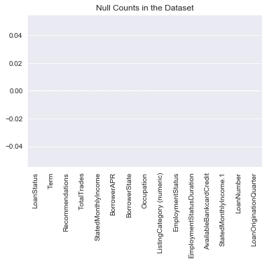

```python
# Verifying that there are no nulls again
null_counts = df_prosper.isnull().sum()
color = sb.color_palette()[0]
sb.barplot(null_counts.index.values, null_counts, color=color)
plt.title("Null Counts in the Dataset")
plt.xticks(rotation=90);
```

```python
# Checking for and dropping duplicates in the data
df_prosper.duplicated().sum()
df_prosper.drop_duplicates(inplace=True)
df_prosper.duplicated().sum()
df_prosper.shape
```

```
(102432, 15)
```

> Now we have dropped the nulls and the duplicates, we can now start visualizing the categorical variables in the dataset. I will start with the outcome variable (the dependent variable) which is LoanStatus

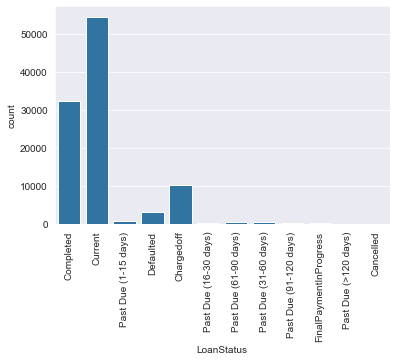

```python
# Plotting bars and boxes for each categorical variable
sb.countplot(data=df_prosper, x="LoanStatus", color=color)
plt.xticks(rotation=90);
```

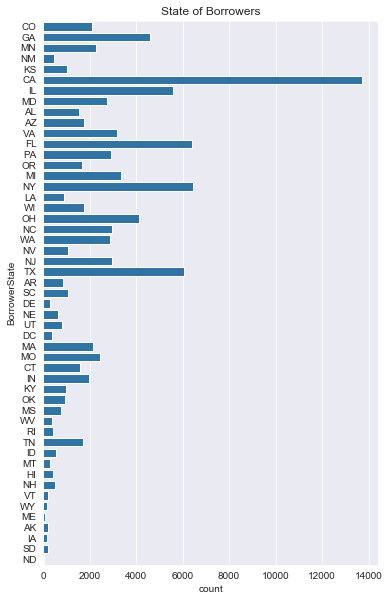

```python
# Visualizing the state where borrowers live
plt.figure(figsize=(6,10))
sb.countplot(data=df_prosper, y="BorrowerState", color=color)
plt.title("State of Borrowers");
```

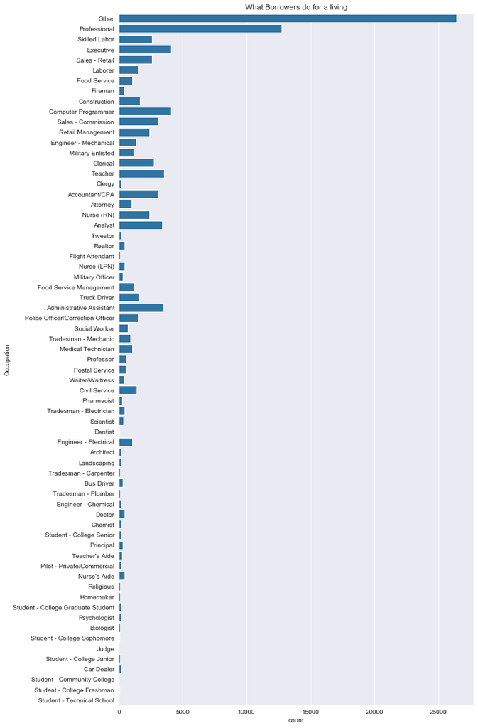

```python
# Visualizing the occupation of Borrowers
plt.figure(figsize=(10,20))
sb.countplot(data=df_prosper, y="Occupation", color=color)
plt.title("What Borrowers do for a living");
```

> The category of work of majority of the borrowers are "Others". This is vague and it captures over 25000 of the borrowing population in this dataset. For those who declare their source of living, majority are Professionals followed by Executives, Computer Programmers, Teachers, Analysts, Administrative Assistants among others. It is worth noting that the students (of various categories), religious, Car Dealer, Flight Attendant and Judge rarely takes loan.

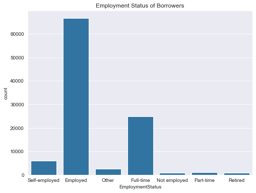

```python
# Visualizing the employment status of Borrowers
plt.figure(figsize=(8,6))
sb.countplot(data=df_prosper, x="EmploymentStatus", color=color)
plt.title("Employment Status of Borrowers");
```

> It appears that most borrowers have one form of employment or the other. Only a few are not employed or retired. In fact over about 25000 borrowers are in full-time employment.

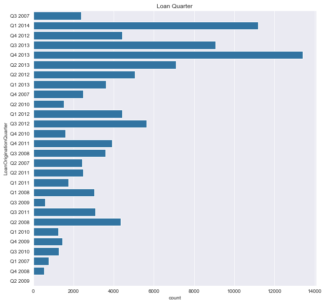

```python
# Visualizing the quarter in which each loan originated
plt.figure(figsize=(10,10))
sb.countplot(data=df_prosper, y="LoanOriginationQuarter", color=color)
plt.title("Loan Quarter");
```

> Next, I will visualize the quantitative variables in this dataset one after the other using histogram. Shall we? Of course, we shall.

```python
# First, I want to describe the quantitative variables
df_prosper.describe()
```

|  | Term | Recommendations | TotalTrades | StatedMonthlyIncome | BorrowerAPR | ListingCategory (numeric) | EmploymentStatusDuration | AvailableBankcardCredit | StatedMonthlyIncome.1 | LoanNumber |
| --- | --- | --- | --- | --- | --- | --- | --- | --- | --- | --- |
| count | 102432.000000 | 102432.000000 | 102432.000000 | 1.024320e+05 | 102432.000000 | 102432.000000 | 102432.000000 | 102432.000000 | 1.024320e+05 | 102432.000000 |
| mean | 41.240862 | 0.050228 | 23.268676 | 5.711377e+03 | 0.221070 | 3.035184 | 96.921802 | 11276.078052 | 5.711377e+03 | 74191.209944 |
| std | 10.791989 | 0.342739 | 11.873685 | 7.708086e+03 | 0.081354 | 4.088550 | 93.916812 | 19865.760401 | 7.708086e+03 | 35107.853358 |
| min | 12.000000 | 0.000000 | 0.000000 | 0.000000e+00 | 0.006530 | 0.000000 | 0.000000 | 0.000000 | 0.000000e+00 | 7495.000000 |
| 25% | 36.000000 | 0.000000 | 15.000000 | 3.333333e+03 | 0.157130 | 1.000000 | 27.000000 | 900.000000 | 3.333333e+03 | 44550.750000 |
| 50% | 36.000000 | 0.000000 | 22.000000 | 4.830458e+03 | 0.211660 | 1.000000 | 68.000000 | 4156.500000 | 4.830458e+03 | 72953.500000 |
| 75% | 36.000000 | 0.000000 | 30.000000 | 6.964083e+03 | 0.287280 | 3.000000 | 138.000000 | 13328.250000 | 6.964083e+03 | 102684.250000 |
| max | 60.000000 | 39.000000 | 126.000000 | 1.750003e+06 | 0.423950 | 20.000000 | 755.000000 | 646285.000000 | 1.750003e+06 | 136486.000000 |

> Some of these variables have outliers. These can be seen in the difference btween the 75th percentile and the maximum. Generally, Recommendations, StatedMonthlyIncome, AvailableBankcardCredit, EmploymentStatusDuration and ListingCategory all exhibits high levels of outliers. So, I may have to use scale transformations while visualizing them.

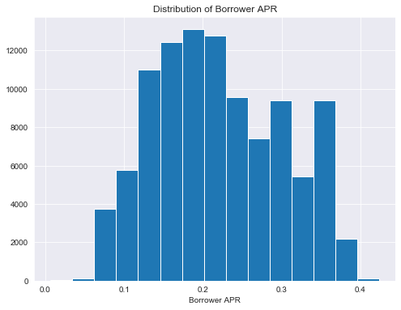

```python
# Visualizing the Borrower APR variable
plt.figure(figsize=[8, 6])
plt.hist(data = df_prosper, x = "BorrowerAPR", bins = 15);
plt.xlabel("Borrower APR")
plt.title("Distribution of Borrower APR");
```

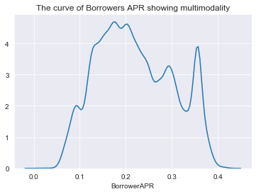

```python
# Visualizing the curve of the APR
sb.distplot(df_prosper["BorrowerAPR"], hist=False, bins=15)
plt.title("The curve of Borrowers APR showing multimodality");
```

> The BorrowerAPR is multimodal. Values are mainly between 0.1 and 0.4. Next, we look at the Term of loans.

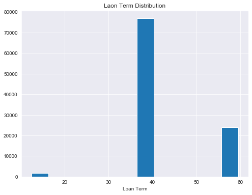

```python
# Visualizing loan term
plt.figure(figsize=[8, 6])
plt.hist(data = df_prosper, x = "Term", rwidth=0.8);
plt.xlabel("Loan Term")
plt.title("Laon Term Distribution");
```

> The LoanTerm is a discrete variable and most loan terms are between 36 and 40 months. Next, we visualize Recommendations

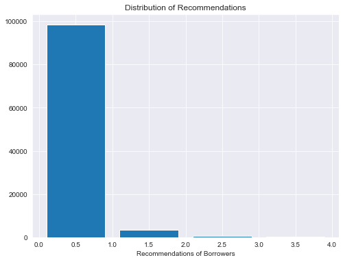

```python
# Visualizing recommendations
plt.figure(figsize=[8, 6])
bins = [0,1,2,3,4]
plt.hist(data = df_prosper, x = "Recommendations", rwidth = 0.8, bins=bins);
plt.xlabel("Recommendations of Borrowers")
plt.title("Distribution of Recommendations");
```

> Recommendations is also a discrete variable. Most Borrowers were not recommended. Of the 3996 that were recommended, 75% of them have only one recommendation.

```python
# Describing those with recommendations
df_prosper[df_prosper["Recommendations"] > 0].describe()
```

|  | Term | Recommendations | TotalTrades | StatedMonthlyIncome | BorrowerAPR | ListingCategory (numeric) | EmploymentStatusDuration | AvailableBankcardCredit | StatedMonthlyIncome.1 | LoanNumber |
| --- | --- | --- | --- | --- | --- | --- | --- | --- | --- | --- |
| count | 3996.000000 | 3996.000000 | 3996.000000 | 3996.000000 | 3996.000000 | 3996.000000 | 3996.000000 | 3996.000000 | 3996.000000 | 3996.000000 |
| mean | 37.027027 | 1.287538 | 21.171421 | 4565.577327 | 0.201695 | 2.062062 | 70.726476 | 11318.798048 | 4565.577327 | 36335.553053 |
| std | 5.927410 | 1.190978 | 12.688110 | 3411.677733 | 0.084154 | 2.689181 | 76.099938 | 24246.291986 | 3411.677733 | 22133.136685 |
| min | 12.000000 | 1.000000 | 1.000000 | 0.000000 | 0.013250 | 0.000000 | 0.000000 | 0.000000 | 0.000000 | 7620.000000 |
| 25% | 36.000000 | 1.000000 | 12.000000 | 2500.000000 | 0.135620 | 0.000000 | 18.000000 | 348.000000 | 2500.000000 | 21387.750000 |
| 50% | 36.000000 | 1.000000 | 19.000000 | 3916.666667 | 0.184540 | 1.000000 | 45.000000 | 2659.500000 | 3916.666667 | 31319.000000 |
| 75% | 36.000000 | 1.000000 | 28.000000 | 5833.333333 | 0.262920 | 3.000000 | 96.000000 | 11358.750000 | 5833.333333 | 42035.250000 |
| max | 60.000000 | 39.000000 | 103.000000 | 41666.666667 | 0.413550 | 20.000000 | 522.000000 | 366529.000000 | 41666.666667 | 136309.000000 |

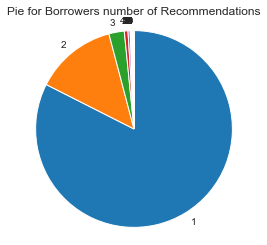

```python
# Using pie to see the recommendations
recom = df_prosper[df_prosper["Recommendations"] > 0]
sorted_counts = recom['Recommendations'].value_counts();
plt.pie(sorted_counts, labels=sorted_counts.index, startangle=90,counterclock=False)
plt.axis("square")
plt.title("Pie for Borrowers number of Recommendations");
```

> For those that were recommended, the number of recommendations are mostly one or two. A few threes, and scanty others. Next, we look at StatedMonthlyIncome, AvailableBankcardCredit, ListingCategory, TotalTrades, and EmploymentStatusDuration.

[figure not shown]

```python
# Visualizing Stated Monthly Income
plt.figure(figsize=[8, 6])
#bins = [10000, 20000,30000,40000,50000,60000]
plt.hist(data = df_prosper, x = "StatedMonthlyIncome", bins = bins);
plt.xlabel("Stated Monthly Income of Borrowers")
plt.title("Distribution of Stated Monthly Income of Borrowers");
```

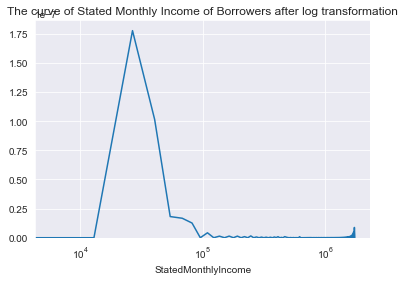

```python
# Visualizing the curve of the Stated Monthly Income Using Transformation
sb.distplot(df_prosper["StatedMonthlyIncome"], hist=False)
plt.xscale("log")
plt.title("The curve of Stated Monthly Income of Borrowers after log transformation");
```

> The distribution of StatedMonthlyIncome is skewed to the right. Most borrowers earn below $20,000USD$ per month.

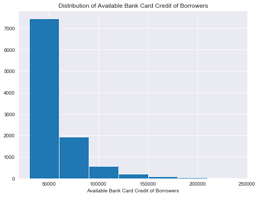

```python
# Visualizing Available Bank Card Credit by tweaking the bins
plt.figure(figsize=[8, 6])
bins = [30000,60000,90000,120000,150000,180000,210000,240000]
plt.hist(data = df_prosper, x = "AvailableBankcardCredit", bins=bins);
#plt.xscale("log")
plt.xlabel("Available Bank Card Credit of Borrowers")
plt.title("Distribution of Available Bank Card Credit of Borrowers");
```

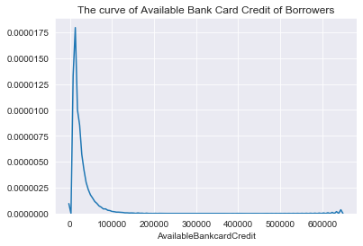

```python
# Visualizing the curve of the Available Bank Card Credit
sb.distplot(df_prosper["AvailableBankcardCredit"], hist=False, bins=15)
plt.title("The curve of Available Bank Card Credit of Borrowers");
```

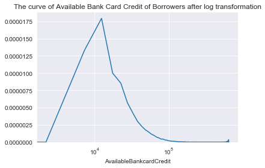

```python
# Visualizing the curve of the Available Bank Credit Using Transformation
sb.distplot(df_prosper["AvailableBankcardCredit"], hist=False)
plt.xscale("log")
plt.title("The curve of Available Bank Card Credit of Borrowers after log transformation");
```

> Available Bank Card Credit of Borrowers is highly skewed. Most of the borrowers have less than $50000USD$ on their credit card. Even the log transformation shows this.

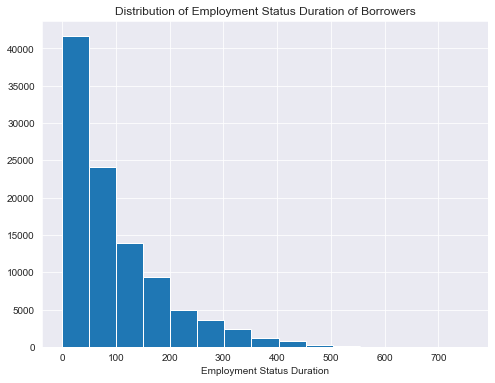

```python
# Visualizing the Employment Status Duration variable
plt.figure(figsize=[8, 6])
plt.hist(data = df_prosper, x = "EmploymentStatusDuration", bins = 15);
plt.xlabel("Employment Status Duration")
plt.title("Distribution of Employment Status Duration of Borrowers");
```

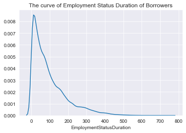

```python
# Visualizing the curve of the EmploymentStatusDuration
sb.distplot(df_prosper["EmploymentStatusDuration"], hist=False, bins=15)
plt.title("The curve of Employment Status Duration of Borrowers");
```

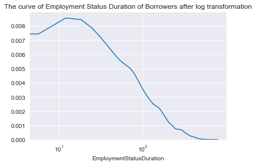

```python
# Visualizing the curve of the EmploymentStatusDuration using transformation
sb.distplot(df_prosper["EmploymentStatusDuration"], hist=False, bins=15)
plt.xscale("log")
plt.title("The curve of Employment Status Duration of Borrowers after log transformation");
```

> Without transformation, the Employment Status Duration of Borrowers is also skewed to the right. Only a few borrowers have above 200 months of Employment Duration. After log transformation, we can see that the curve tends towards $S$ shape.

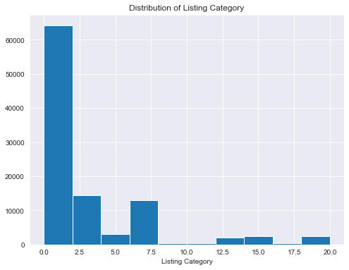

```python
# Visualizing the Listing Category variable
plt.figure(figsize=[8, 6])
plt.hist(data = df_prosper, x = "ListingCategory (numeric)");
plt.xlabel("Listing Category")
plt.title("Distribution of Listing Category");
```

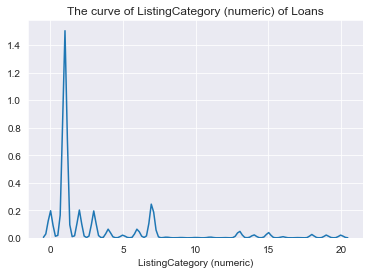

```python
# Visualizing the curve of theListingCategory (numeric)
sb.distplot(df_prosper["ListingCategory (numeric)"], hist=False)
plt.title("The curve of ListingCategory (numeric) of Loans");
```

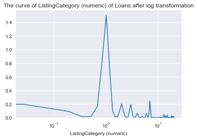

```python
# Visualizing the curve of theListingCategory (numeric) using transformation
sb.distplot(df_prosper["ListingCategory (numeric)"], hist=False)
plt.xscale("log")
plt.title("The curve of ListingCategory (numeric) of Loans after log transformation");
```

### Discuss the distribution(s) of your variable(s) of interest. Were there any unusual points? Did you need to perform any transformations?

> My variable of interest is LoanStatus. It is a categorical variable. Majority of the loans are current and a few are charged off. Some have been completed while others are past due for over 60 days.

### Of the features you investigated, were there any unusual distributions? Did you perform any operations on the data to tidy, adjust, or change the form of the data? If so, why did you do this?

> As shown in the series of analysis, most of the numeric variables (e.g StatedMonthlyIncome, AvailableBankcardCredit, EmploymentStatusDuration etc) are skewed to the right. This is because there are outliers in such variables. I performed some transformations. I perform log transformations to better understand the distribution of the variables. For some variables, I tinkered with the bin sizes for better visualization. In the case of Recommendations, I also partitioned the variable into normal and outliers for better visualization. I used pie chart to view the outliers.

## Bivariate Exploration

> In this section, I will investigate the relationship of some of my variables to the variable of interest which as earlier stated is loan status. I want to know the variables that affect loan status. This section will deal with Bivariate investigations. I shall focus on such variables as Borrower APR, StatedMonthlyIncome, EmploymentStatus, EmploymentStatusDuration, LoanTerm, AvailableBankcardCredit, Recommendations, State of Borrowers among others.

> Shall we begin?

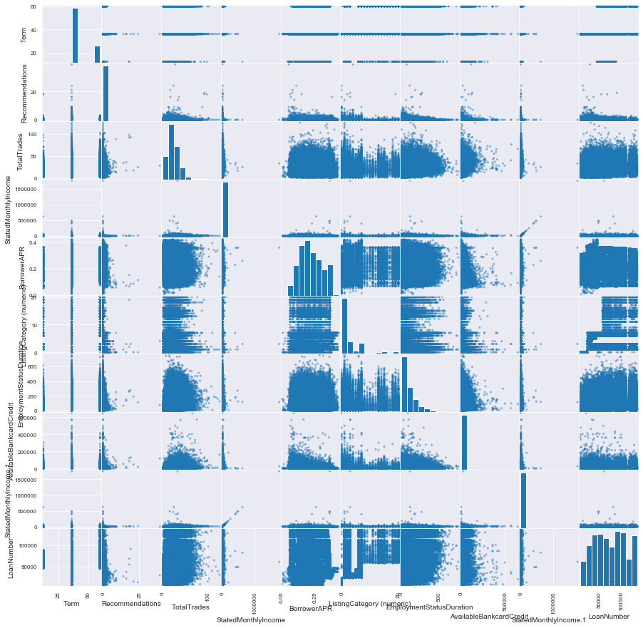

```python
# Visualizing the relationship between the numeric variables
pd.plotting.scatter_matrix(df_prosper, figsize=(15,15));
```

> This big overview does not appear to be easy to read. Next, I will use scatter plots to show the relationship between the numeric variables of interest. This I believe will help me understand loan status better.

> Then, I will use violin and boxplots to explore the relationship between Loan status and the numeric variables.

> Finally in this section, I will use clustered bar charts to explore the relationship between Loan status and the other categorical variables of interest.

> Let us continue.

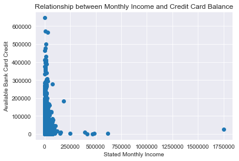

```python
# Visualizing the relationship between StatedMonthlyIncome and AvailableBankcardCredit
plt.scatter(data=df_prosper, x = "StatedMonthlyIncome", y = "AvailableBankcardCredit")
plt.ylabel("Available Bank Card Credit")
plt.xlabel("Stated Monthly Income")
plt.title("Relationship between Monthly Income and Credit Card Balance");
```

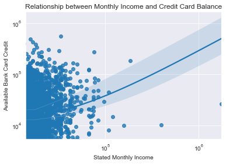

```python
# Visualizing the relationship between StatedMonthlyIncome and AvailableBankcardCredit
sb.regplot(data=df_prosper, x = "StatedMonthlyIncome", y = "AvailableBankcardCredit")
plt.xscale("log")
plt.yscale("log")
plt.ylabel("Available Bank Card Credit")
plt.xlabel("Stated Monthly Income")
plt.title("Relationship between Monthly Income and Credit Card Balance");
```

> The relationship between StatedMonthlyIncome and AvailableBankcardCredit is not so clear when plotted without transformation. After transformation it is clear that there is a weak multiplcative (non-linear) increasing relationship between the two. I had expected the relationship to be strong and linear.

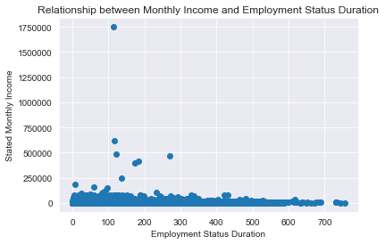

```python
# Visualizing the relationship between StatedMonthlyIncome and EmploymentStatusDuration
plt.scatter(data=df_prosper, x = "EmploymentStatusDuration", y = "StatedMonthlyIncome")
plt.ylabel("Stated Monthly Income")
plt.xlabel("Employment Status Duration")
plt.title("Relationship between Monthly Income and Employment Status Duration");
```

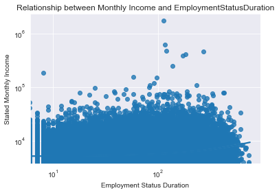

```python
# Visualizing the relationship between StatedMonthlyIncome and EmploymentStatusDuration
sb.regplot(data=df_prosper, x = "EmploymentStatusDuration", y = "StatedMonthlyIncome")
plt.xscale("log")
plt.yscale("log")
plt.ylabel("Stated Monthly Income")
plt.xlabel("Employment Status Duration")
plt.title("Relationship between Monthly Income and EmploymentStatusDuration");
```

> The relationship between EmploymentStatusDuration and StatedMonthlyIncome is so weak. I had expected monthly income to increase as employment duration increases.

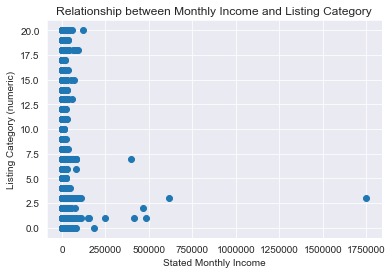

```python
# Visualizing the relationship between StatedMonthlyIncome and ListingCategory (numeric)
plt.scatter(data=df_prosper, x = "StatedMonthlyIncome", y = "ListingCategory (numeric)")
plt.ylabel("Listing Category (numeric)")
plt.xlabel("Stated Monthly Income")
plt.title("Relationship between Monthly Income and Listing Category");
```

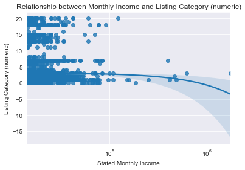

```python
# Visualizing the relationship between StatedMonthlyIncome and EmploymentStatusDuration
sb.regplot(data=df_prosper, x = "StatedMonthlyIncome", y = "ListingCategory (numeric)")
plt.xscale("log")
#plt.yscale("log")
plt.ylabel("Listing Category (numeric)")
plt.xlabel("Stated Monthly Income")
plt.title("Relationship between Monthly Income and Listing Category (numeric)");
```

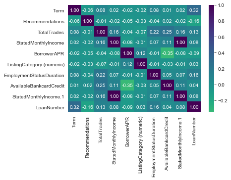

```python
# Visualizing the correlation among the numeric variables
sb.heatmap(df_prosper.corr(), annot = True, fmt = ".2f", cmap = "viridis_r", center = 0);
```

> This relationship is negative. Th higher the stated monthly income, the lower the category of loans applied for. It should be noted that these lower categories are concerned mainly with long term investments such as Home Improvement, Boat and others. As can be seen from the correlations heat map, the correlations between the variables are very weak. Next, I will visualize the discrete variables.

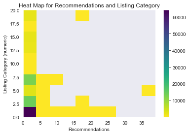

```python
# Visualizing the discrete variables using heatmap
plt.hist2d(data=df_prosper, x="Recommendations", y = "ListingCategory (numeric)", cmap = "viridis_r", cmin = 0.5);
plt.colorbar()
plt.xlabel("Recommendations")
plt.ylabel("Listing Category (numeric)");
plt.title("Heat Map for Recommendations and Listing Category");
```

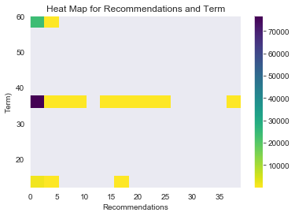

```python
# Visualizing loan term and Recommendations
plt.hist2d(data=df_prosper, x="Recommendations", y = "Term", cmap = "viridis_r", bins=15, cmin = 0.5);
plt.colorbar()
plt.xlabel("Recommendations")
plt.ylabel("Term)");
plt.title("Heat Map for Recommendations and Term");
```

> Now, I will focus on how some variables affect LoanStatus which is the variable of interest here.

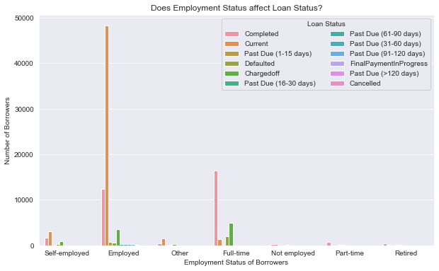

```python
# Visualizing the relationship between variables and Loan Status
plt.figure(figsize=(10,6))
sb.countplot(data = df_prosper, x = "EmploymentStatus", hue = "LoanStatus")
plt.legend(loc = 1, ncol = 2, framealpha = 1, title = "Loan Status")
plt.ylabel("Number of Borrowers")
plt.xlabel("Employment Status of Borrowers")
plt.title("Does Employment Status affect Loan Status?");
```

> From this visualization, it can be deduced that most borrowers that hold current loans are employed. Those in full time employment have higher loan completion but they also have the highest number of loans that are charged off.

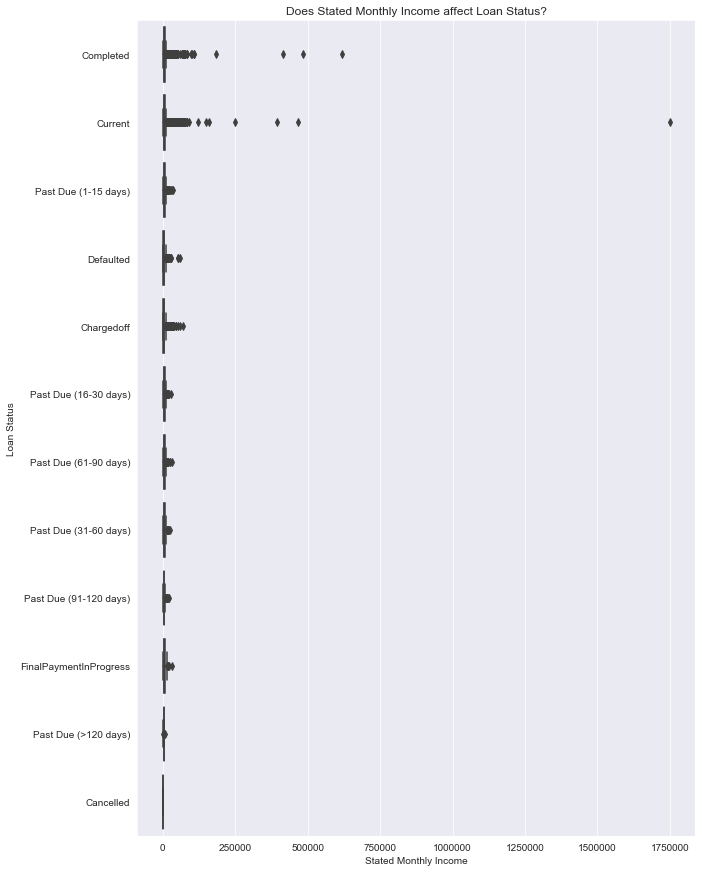

```python
# Visualizing the relationship between variables and Loan Status
color = sb.color_palette()[0]
plt.figure(figsize=(10,15))
sb.boxplot(data = df_prosper, x = "StatedMonthlyIncome", y = "LoanStatus", color = color)
plt.ylabel("Loan Status")
plt.xlabel("Stated Monthly Income")
plt.title("Does Stated Monthly Income affect Loan Status?");
```

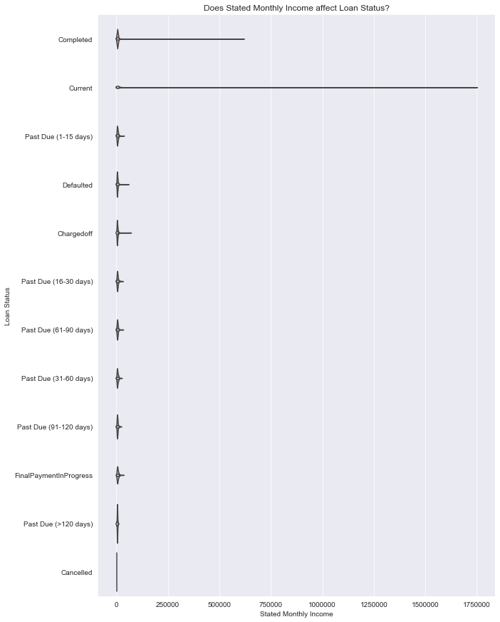

```python
# Visualizing the relationship between variables and Loan Status
plt.figure(figsize=(10,15))
sb.violinplot(data = df_prosper, x = "StatedMonthlyIncome", y = "LoanStatus")
plt.ylabel("Loan Status")
plt.xlabel("Stated Monthly Income")
plt.title("Does Stated Monthly Income affect Loan Status?");
```

> From the two plots, stated monthly income has little effect on loan status. Those with high stated monthly income tend to complete their loans but they also hold more current loans. Perhaps they are easier to extend loan facilities to.

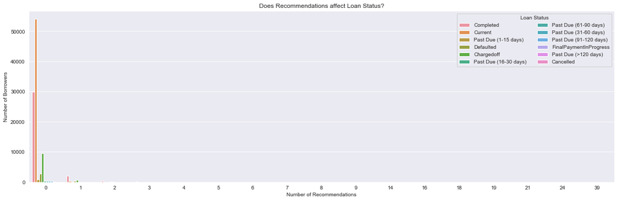

```python
# Visualizing the relationship between variables and Loan Status
# Here I use Recommendations inscluding those who have and those who does not have
plt.figure(figsize=(20,6))
sb.countplot(data = df_prosper, x = "Recommendations", hue = "LoanStatus")
plt.legend(loc = 1, ncol = 2, framealpha = 1, title = "Loan Status")
plt.ylabel("Number of Borrowers")
plt.xlabel("Number of Recommendations")
plt.title("Does Recommendations affect Loan Status?");
```

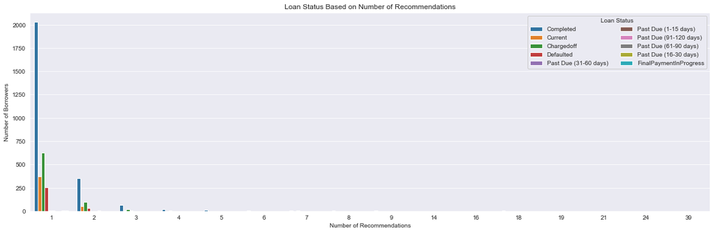

```python
# Visualizing the relationship between variables and Loan Status
# Here I used only those who have recommendations
plt.figure(figsize=(20,6))
sb.countplot(data = recom, x = "Recommendations", hue = "LoanStatus")
plt.legend(loc = 1, ncol = 2, framealpha = 1, title = "Loan Status")
plt.ylabel("Number of Borrowers")
plt.xlabel("Number of Recommendations")
plt.title("Loan Status Based on Number of Recommendations");
```

> From the two charts above, we can see that Recommendations have a great effect on loan status. A high number of those whose loans were charged off do not have recommendations. It can also be deduced that the higher the number of recommendations the higher the loan completion rate.

```python
# Now I want to look at how loan term affects loan status
df_prosper.Term.describe()
```

```
count    102432.000000
mean         41.240862
std          10.791989
min          12.000000
25%          36.000000
50%          36.000000
75%          36.000000
max          60.000000
Name: Term, dtype: float64
```

```python
df_prosper.Term.value_counts()
```

```
36    76836
60    23982
12     1614
Name: Term, dtype: int64
```

```python
# Creating a new column for term called term_category
bin_edges = [12,36,60]
bin_names = ["short", "long"]
df_prosper["term_category"] = pd.cut(df_prosper["Term"], bin_edges, labels = bin_names)
```

```python
# Checking the newly created column
column_lister(df_prosper)
df_prosper.term_category.value_counts()
```

```
0 LoanStatus
1 Term
2 Recommendations
3 TotalTrades
4 StatedMonthlyIncome
5 BorrowerAPR
6 BorrowerState
7 Occupation
8 ListingCategory (numeric)
9 EmploymentStatus
10 EmploymentStatusDuration
11 AvailableBankcardCredit
12 StatedMonthlyIncome.1
13 LoanNumber
14 LoanOriginationQuarter
15 term_category
```

```
short    76836
long     23982
Name: term_category, dtype: int64
```

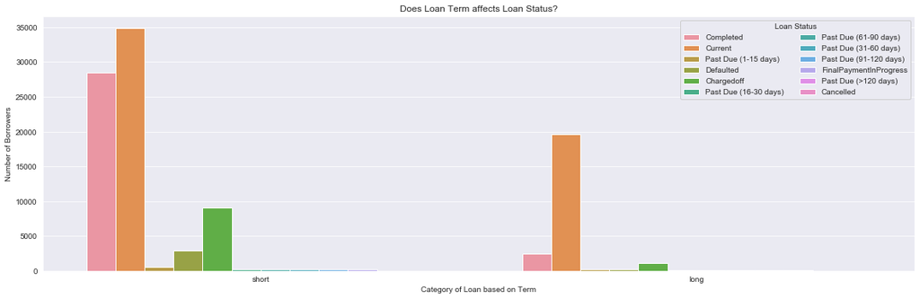

```python
# Visualizing term_category and LoanStatus
plt.figure(figsize=(20,6))
sb.countplot(data = df_prosper, x = "term_category", hue = "LoanStatus")
plt.legend(loc = 1, ncol = 2, framealpha = 1, title = "Loan Status")
plt.ylabel("Number of Borrowers")
plt.xlabel("Category of Loan based on Term")
plt.title("Does Loan Term affects Loan Status?");
```

```python
# Categorizing Available Bank Card Credit and Stated Monthly Income
df_prosper.StatedMonthlyIncome.describe()
```

```
count    1.024320e+05
mean     5.711377e+03
std      7.708086e+03
min      0.000000e+00
25%      3.333333e+03
50%      4.830458e+03
75%      6.964083e+03
max      1.750003e+06
Name: StatedMonthlyIncome, dtype: float64
```

```python
bin_edges2 = [0.000000e+00,3.333333e+03,4.830458e+03,6.964083e+03,1.750003e+06]
bin_names2 = ["low", "medium","high", "very_high"]
df_prosper["income_category"] = pd.cut(df_prosper["StatedMonthlyIncome"], bin_edges2, labels = bin_names2)
```

```python
df_prosper.AvailableBankcardCredit.describe()
```

```
count    102432.000000
mean      11276.078052
std       19865.760401
min           0.000000
25%         900.000000
50%        4156.500000
75%       13328.250000
max      646285.000000
Name: AvailableBankcardCredit, dtype: float64
```

```python
bin_edges3 = [0.000000,900.000000,4156.500000,13328.250000,646285.000000]
bin_names3 = ["low", "medium","high", "very_high"]
df_prosper["card_credit_category"] = pd.cut(df_prosper["AvailableBankcardCredit"], bin_edges3, labels = bin_names3)
```

```python
# Categorizing Available Bank Card Credit and Stated Monthly Income
df_prosper.EmploymentStatusDuration.describe()
```

```
count    102432.000000
mean         96.921802
std          93.916812
min           0.000000
25%          27.000000
50%          68.000000
75%         138.000000
max         755.000000
Name: EmploymentStatusDuration, dtype: float64
```

```python
bin_edges4 = [0.000000,27.000000,68.000000,138.000000,755.000000]
bin_names4 = ["low", "medium","high", "very_high"]
df_prosper["employment_status_category"] = pd.cut(df_prosper["EmploymentStatusDuration"], bin_edges4, labels = bin_names4)
```

```python
column_lister(df_prosper)
```

```
0 LoanStatus
1 Term
2 Recommendations
3 TotalTrades
4 StatedMonthlyIncome
5 BorrowerAPR
6 BorrowerState
7 Occupation
8 ListingCategory (numeric)
9 EmploymentStatus
10 EmploymentStatusDuration
11 AvailableBankcardCredit
12 StatedMonthlyIncome.1
13 LoanNumber
14 LoanOriginationQuarter
15 term_category
16 income_category
17 card_credit_category
18 employment_status_category
```

```python
df_prosper.head()
```

|  | LoanStatus | Term | Recommendations | TotalTrades | StatedMonthlyIncome | BorrowerAPR | BorrowerState | Occupation | ListingCategory (numeric) | EmploymentStatus | EmploymentStatusDuration | AvailableBankcardCredit | StatedMonthlyIncome.1 | LoanNumber | LoanOriginationQuarter | term_category | income_category | card_credit_category | employment_status_category |
| --- | --- | --- | --- | --- | --- | --- | --- | --- | --- | --- | --- | --- | --- | --- | --- | --- | --- | --- | --- |
| 0 | Completed | 36 | 0 | 11.0 | 3083.333333 | 0.16516 | CO | Other | 0 | Self-employed | 2.0 | 1500.0 | 3083.333333 | 19141 | Q3 2007 | short | low | medium | low |
| 1 | Current | 36 | 0 | 29.0 | 6125.000000 | 0.12016 | CO | Professional | 2 | Employed | 44.0 | 10266.0 | 6125.000000 | 134815 | Q1 2014 | short | high | high | medium |
| 3 | Current | 36 | 0 | 26.0 | 2875.000000 | 0.12528 | GA | Skilled Labor | 16 | Employed | 113.0 | 30754.0 | 2875.000000 | 77296 | Q4 2012 | short | low | very_high | high |
| 4 | Current | 36 | 0 | 39.0 | 9583.333333 | 0.24614 | MN | Executive | 2 | Employed | 44.0 | 695.0 | 9583.333333 | 102670 | Q3 2013 | short | very_high | low | medium |
| 5 | Current | 60 | 0 | 47.0 | 8333.333333 | 0.15425 | NM | Professional | 1 | Employed | 82.0 | 86509.0 | 8333.333333 | 123257 | Q4 2013 | long | very_high | very_high | high |

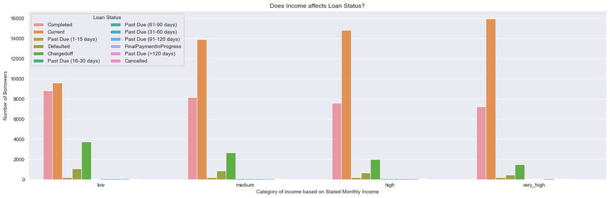

```python
# Visualizing term_category and LoanStatus
plt.figure(figsize=(20,6))
sb.countplot(data = df_prosper, x = "income_category", hue = "LoanStatus")
plt.legend(loc = 2, ncol = 2, framealpha = 1, title = "Loan Status")
plt.ylabel("Number of Borrowers")
plt.xlabel("Category of income based on Stated Monthly Income")
plt.title("Does Income affects Loan Status?");
```

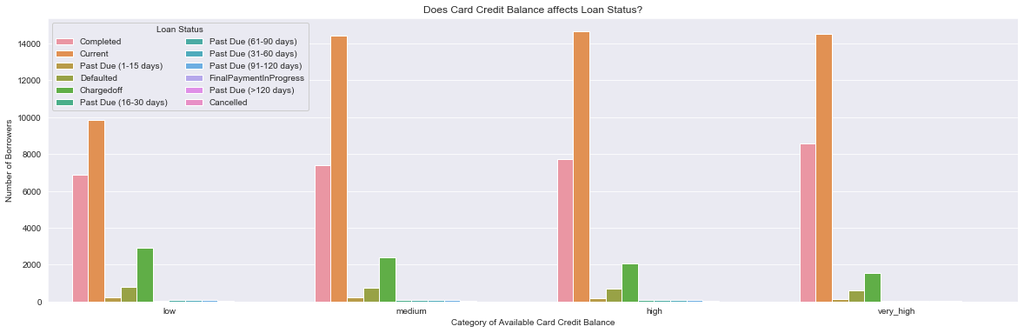

```python
# Visualizing term_category and LoanStatus
plt.figure(figsize=(20,6))
sb.countplot(data = df_prosper, x = "card_credit_category", hue = "LoanStatus")
plt.legend(loc = 2, ncol = 2, framealpha = 1, title = "Loan Status")
plt.ylabel("Number of Borrowers")
plt.xlabel("Category of Available Card Credit Balance")
plt.title("Does Card Credit Balance affects Loan Status?");
```

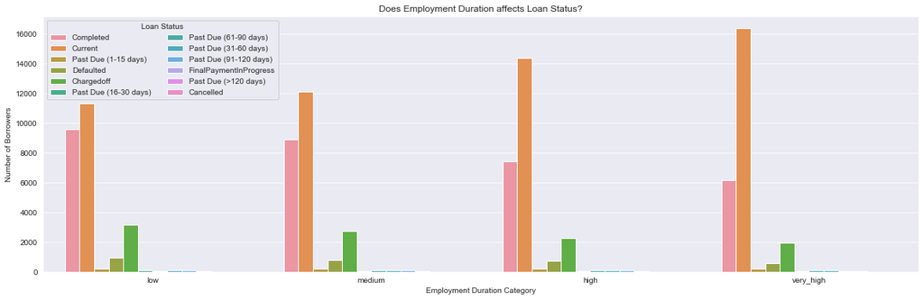

```python
# Visualizing term_category and LoanStatus
plt.figure(figsize=(20,6))
sb.countplot(data = df_prosper, x = "employment_status_category", hue = "LoanStatus")
plt.legend(loc = 2, ncol = 2, framealpha = 1, title = "Loan Status")
plt.ylabel("Number of Borrowers")
plt.xlabel("Employment Duration Category")
plt.title("Does Employment Duration affects Loan Status?");
```

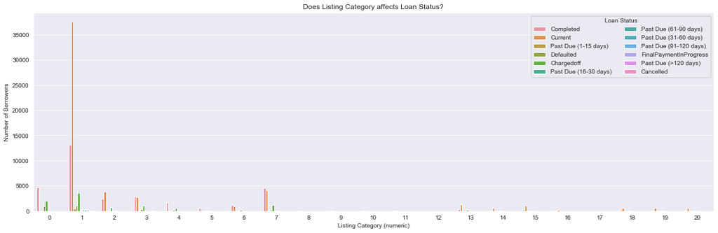

```python
# Visualizing listing category and LoanStatus
plt.figure(figsize=(20,6))
sb.countplot(data = df_prosper, x = "ListingCategory (numeric)", hue = "LoanStatus")
plt.legend(loc = 1, ncol = 2, framealpha = 1, title = "Loan Status")
plt.ylabel("Number of Borrowers")
plt.xlabel("Listing Category (numeric)")
plt.title("Does Listing Category affects Loan Status?");
```

> From the immediate four charts, it appears that the higher the card balance the higher the rate of current and completed loans and the lower the rate of defaults and charged offs.This relationship is consistently to some extent for employment duration and stated monthly income. It is also worth noting that the lower category loans have high rate of loan completion.

> Now, the relationship between the variables and Loan Status is becoming much more clearer.

### Talk about some of the relationships you observed in this part of the investigation. How did the feature(s) of interest vary with other features in the dataset?

> As documented above, Loan status varies in different ways.
> - Borrrowers in full time employment have higher rate of loan completion.
> - The higher the number of recommendations, the higher the loan completion rate.
> - Long term loans have better loan outcome status than short term loans.
> - The higher the employment status, stated monthly income, and available bank card credit of borrowers, the lower the rate of defaults and charged offs.
> - Also, these lower category loans have high rate of loan completion.

### Did you observe any interesting relationships between the other features (not the main feature(s) of interest)?

> Yes. I observed that borrowers with high stated income often go for lower category loans. These loans are usually long term. Such loans include Boat loans, Business Loans, Home Improvement etc. Moreover, I observed that the relationship between monthly income and employment duration, although positive, is very weak.

```python
# Saving the dataset as it is now for use tomorrow
#df_prosper.to_csv("prosper_extract_adjusted.csv", index=False)
df_prosper = pd.read_csv("prosper_extract_adjusted.csv")
df_prosper.head()
```

|  | LoanStatus | Term | Recommendations | TotalTrades | StatedMonthlyIncome | BorrowerAPR | BorrowerState | Occupation | ListingCategory (numeric) | EmploymentStatus | EmploymentStatusDuration | AvailableBankcardCredit | StatedMonthlyIncome.1 | LoanNumber | LoanOriginationQuarter | term_category | income_category | card_credit_category | employment_status_category |
| --- | --- | --- | --- | --- | --- | --- | --- | --- | --- | --- | --- | --- | --- | --- | --- | --- | --- | --- | --- |
| 0 | Completed | 36 | 0 | 11.0 | 3083.333333 | 0.16516 | CO | Other | 0 | Self-employed | 2.0 | 1500.0 | 3083.333333 | 19141 | Q3 2007 | short | low | medium | low |
| 1 | Current | 36 | 0 | 29.0 | 6125.000000 | 0.12016 | CO | Professional | 2 | Employed | 44.0 | 10266.0 | 6125.000000 | 134815 | Q1 2014 | short | high | high | medium |
| 2 | Current | 36 | 0 | 26.0 | 2875.000000 | 0.12528 | GA | Skilled Labor | 16 | Employed | 113.0 | 30754.0 | 2875.000000 | 77296 | Q4 2012 | short | low | very_high | high |
| 3 | Current | 36 | 0 | 39.0 | 9583.333333 | 0.24614 | MN | Executive | 2 | Employed | 44.0 | 695.0 | 9583.333333 | 102670 | Q3 2013 | short | very_high | low | medium |
| 4 | Current | 60 | 0 | 47.0 | 8333.333333 | 0.15425 | NM | Professional | 1 | Employed | 82.0 | 86509.0 | 8333.333333 | 123257 | Q4 2013 | long | very_high | very_high | high |

## Multivariate Exploration

> In this section, I will investigate this dataset further by creating multivariate plots. Since I have begin to see pattern on how some variables affect Loan Status, I will pull these variables together in a plot and try to understand them much deeper.

> Let us begin.

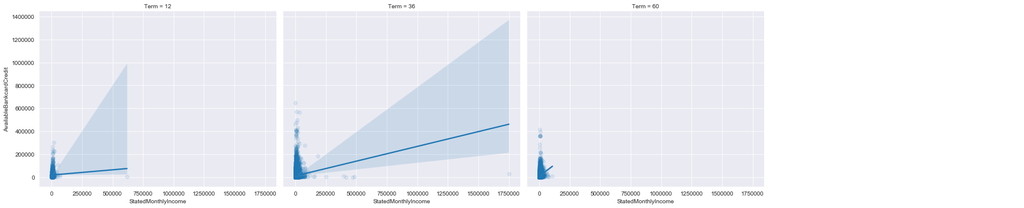

```python
# Visualizing the relationship of term to Available Bank Card Credit and Stated Monthly Income
g=sb.FacetGrid(data = df_prosper, aspect=1.2, height=5, col='Term', col_wrap=4)
g.map(sb.regplot, 'StatedMonthlyIncome', 'AvailableBankcardCredit', x_jitter=0.04, scatter_kws={'alpha':0.1});
g.add_legend();
```

> From the above charts, it appears that there is a somewhat linear relationship between stated monthly income, available card credit and loan term. As borrowers' monthly income increases, their card credit increases and they tend to go for 36 month term loans.

[figure not shown]

```python
# Visualizing the relationship of Loan Status to Available Bank Card Credit and Income category
plt.figure(figsize = (15,8))
ax = sb.barplot(data = df_prosper, x = "income_category", y = "AvailableBankcardCredit", hue = "LoanStatus")
ax.legend(loc = 2, ncol = 6, framealpha = 1, title = "LoanStatus")
plt.title("How Income and Bank Balance affects Loan Status I");
```

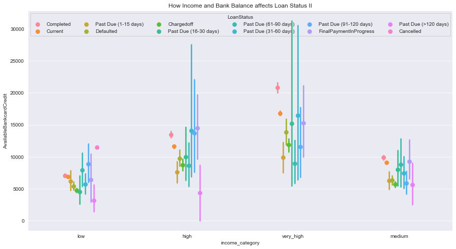

```python
# Visualizing the relationship of Loan Status to Available Bank Card Credit and Income category
plt.figure(figsize = (15,8))
ax = sb.pointplot(data = df_prosper, x = "income_category", y = "AvailableBankcardCredit", hue = "LoanStatus", dodge = 0.3, linestyles = "")
ax.legend(loc = 2, ncol = 6, framealpha = 1, title = "LoanStatus")
plt.title("How Income and Bank Balance affects Loan Status II");
```

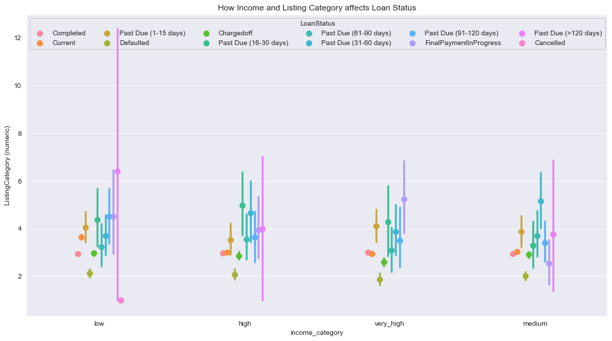

```python
# Visualizing the relationship of Loan Status to Listing Category and Income category
plt.figure(figsize = (15,8))
ax = sb.pointplot(data = df_prosper, x = "income_category", y = "ListingCategory (numeric)", hue = "LoanStatus", dodge = 0.3, linestyles = "")
ax.legend(loc = 2, ncol = 6, framealpha = 1, title = "LoanStatus")
plt.title("How Income and Listing Category affects Loan Status");
```

[figure not shown]

```python
# Visualization of income, card credit, recommendations, and employment duration
fig, ax = plt.subplots(ncols=2, figsize=[12,6])
sb.pointplot(data = df_prosper, x = 'EmploymentStatusDuration', y = 'StatedMonthlyIncome', hue = 'Recommendations',
           palette = 'Purples', linestyles = '', dodge = 0.4, ax=ax[0])
sb.pointplot(data = df_prosper, x = 'EmploymentStatusDuration', y = 'AvailableBankcardCredit', hue = 'Recommendations',
           palette = 'Greens', linestyles = '', dodge = 0.4, ax=ax[1]);
```

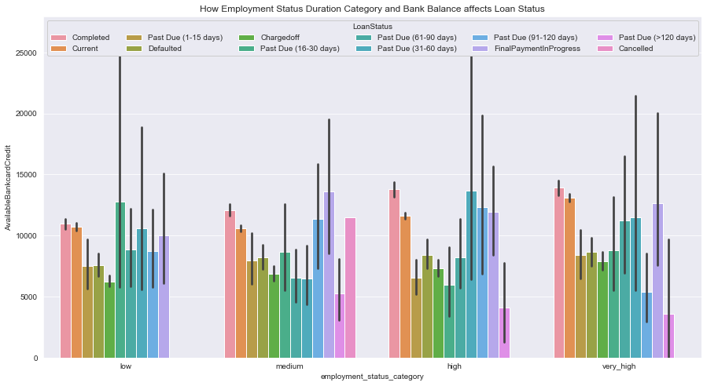

```python
# Visualizing the relationship of employment status category to Available Bank Card and
plt.figure(figsize = (15,8))
ax = sb.barplot(data = df_prosper, x = "employment_status_category", y = "AvailableBankcardCredit", hue = "LoanStatus")
ax.legend(loc = 2, ncol = 6, framealpha = 1, title = "LoanStatus")
plt.title("How Employment Status Duration Category and Bank Balance affects Loan Status");
```

> Available Credit and Employment status duration category does not appear to have a strong effect on loan outcome status. This is surprising.

### Were there any interesting or surprising interactions between features?

> It is surprising to observe that Employment Status Duration and Available Bank card Credit do not have a linear relationship. Even when transformed, the relationship is very weak. I had expected the two to be strongly correlated.

## Conclusions

> Conclusively, although it is clear that the variables analyzed here affects loan status, it is necessary to dig deeper either by adding other variables or by carrying out a regression analysis.

## References

> The following resources were useful either as bibliography or as references in completing this project.
> - https://pandas.pydata.org/docs/reference/api/pandas.cut.html?highlight=cut#pandas.cut
> - https://seaborn.pydata.org/tutorial/axis_grids.html
> - https://seaborn.pydata.org/tutorial/distributions.html
> - https://nextjournal.com/sdanisch/data-types-graphical-marks-and-visual-encoding-channels
> - https://altair-viz.github.io/user_guide/customization.html